# Population Subdivision Activity

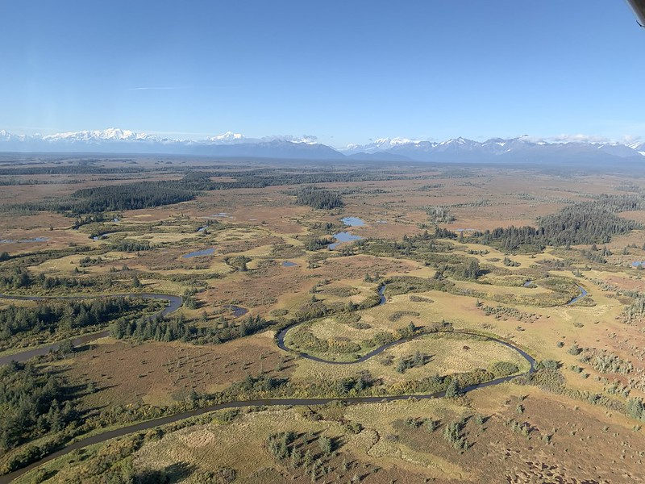

## Overview

This section will focus on estimating the measures of genetic distance and genetic structure. The lecture content for this topic is [here](https://thurstoncounty.gitlab.io/landscape-genetics-workshop/genetic/subdivsion/slides.html).

## The Data

```r
library( gstudio )
data( arapat )
```

The data for this activity is included in the `gstudio` library and represents a set of nuclear co-dominant loci (named *LTRS, WNT, EN, EF, ZMP, AML, ATPS, MP20*) assayed for 363 individuals and partitioned into 3 partitions.

```r
summary( arapat )
```

```
      Species      Cluster      Population        ID         Latitude       Longitude          LTRS          WNT
 Cape     : 75   CBP-C :150   32     : 19   101_10A:  1   Min.   :23.08   Min.   :-114.3   01:01 :147   03:03  :108
 Mainland : 36   NBP-C : 84   75     : 11   101_1A :  1   1st Qu.:24.59   1st Qu.:-113.0   01:02 : 86   01:01  : 82
 Peninsula:252   SBP-C : 18   Const  : 11   101_2A :  1   Median :26.25   Median :-111.5   02:02 :130   01:03  : 77
                 SCBP-A: 75   12     : 10   101_3A :  1   Mean   :26.25   Mean   :-111.7                02:02  : 62
                 SON-B : 36   153    : 10   101_4A :  1   3rd Qu.:27.53   3rd Qu.:-110.5                03:04  :  8
                              157    : 10   101_5A :  1   Max.   :29.33   Max.   :-109.1                (Other): 15
                              (Other):292   (Other):357                                                 NA's   : 11
       EN           EF          ZMP           AML           ATPS          MP20
 01:01  :225   01:01 :219   01:01 : 46   08:08  : 51   05:05  :155   05:07  : 64
 01:02  : 52   01:02 : 52   01:02 : 51   07:07  : 42   03:03  : 69   07:07  : 53
 02:02  : 38   02:02 : 90   02:02 :233   07:08  : 42   09:09  : 66   18:18  : 52
 03:03  : 22   NA's  :  2   NA's  : 33   04:04  : 41   02:02  : 30   05:05  : 48
 01:03  :  7                             07:09  : 22   07:09  : 14   05:06  : 22
 (Other): 16                             (Other):142   08:08  :  9   (Other):119
 NA's   :  3                             NA's   : 23   (Other): 20   NA's   :  5
```

1. Copy over the function `island_frequencies()` created in the slides ( [here](https://thurstoncounty.gitlab.io/landscape-genetics-workshop/genetic/subdivsion/slides.html#14) ). If the mainland population frequency was $p=1.0$ and the island frequency started at $p=0.32$, how many generations does it take for a migration rate of $m=0.10$ with the underlying model of unidirectional migration as depicted in the $N-Island$ diagram?
2. Consider the simple demographic population model with three populations (*Pop-X*, *Pop-Y*, and *Pop-Z*) all connected by symmetric migration (as shown [here](https://thurstoncounty.gitlab.io/landscape-genetics-workshop/genetic/subdivsion/slides.html#17)). If the initial allele frequencies at a simple 2-allele locus are $p_X = 0.25$, $p_Y = 0.50$, and $p_Z = 0.75$, what are the allele frequency for this network of populations at equilibrium if migration is:
   - $m = 0.0$,
   - $m = 0.01$,
   - $m = 0.1$
3. Isolation by physical distance (classically called *IBD*) is a relationship between physical separation of populations and some measure of genetic differences. For the the *arapat* data set, estimate inter-population genetic distance using Nei’s metric and then plot that against inter-population physical distance. Overlay a trendline. Interpret the results, do genetic differences have a relationship with physical separation?
4. Does your interpretation of the *IBD* relationship change if you only use individuals whose `Species == Peninsula`?
5. Is there more structure ($\Phi_{ST}$) among *Species*, *Clusters*, or *Populations* in the *arapat* data set? And how would you suggest analyzing these data after seeing these differences?